# FinalProjectFundamentals

Blackburn

December 13, 2017

Load necessary packages for exploration of data.

```r
library(ggplot2)
library(visdat)
library(dplyr)
library(mosaic)
library(gridExtra)
library(grid)
library(RColorBrewer)
```

Load in the dataset, and see the beginning of the file.

```r
dat <- read.csv("FinalProj.csv", sep = ",", header = TRUE)
head(dat)
```

```
##                City ZipCode ApxAbvGrLivSF ApxBlwGrLivSF ApxTotalLivArea
## 1 East Side of Prov    2906          1565             0            1872
## 2 East Side of Prov    2906          1565             0            1872
## 3 East Side of Prov    2906          1565             0            1872
## 4 East Side of Prov    2906          1565          1300            1872
## 5 East Side of Prov    2906          1565           307            1872
## 6 East Side of Prov    2906          1565           307            1872
##       Cooling NumOfFireplaces TotalBedrooms FullBaths GarageSpaces DOM
## 1 Central Air               2             4         3            3  68
## 2 Central Air               1             5         2            3 251
## 3 Central Air               1             5         2            3  98
## 4 Central Air               3             4         2            3  82
## 5 Central Air               1             3         2            2   3
## 6 Central Air               1             5         2            1   1
##                     ListOffice                       ListAgent
```

[output cut: 41 more lines]

Examine the distribution visually of the different variable types.

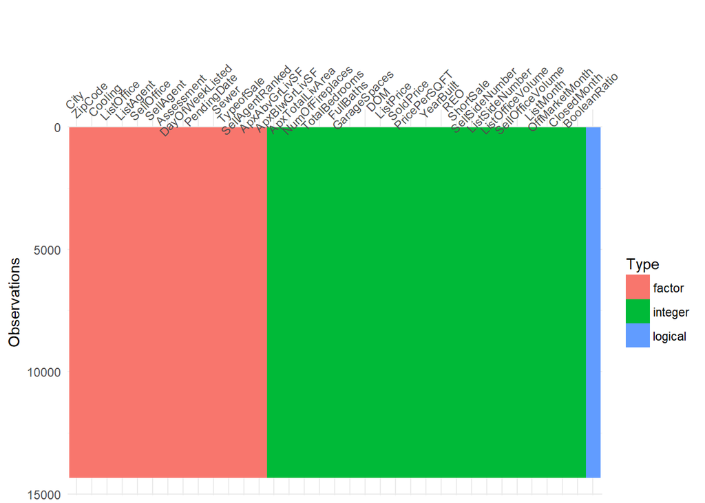

```r
vis_dat(dat)
```

Add a color brewer pallet.

```r
brewer.pal(n = 8, name = "Set2")
```

```
## [1] "#66C2A5" "#FC8D62" "#8DA0CB" "#E78AC3" "#A6D854" "#FFD92F" "#E5C494"
## [8] "#B3B3B3"
```

I completed some exploration of the data, measuring and exploring various variables against each other to look for patterns in the visualizations, and potential changes to make in the Azure ML model.

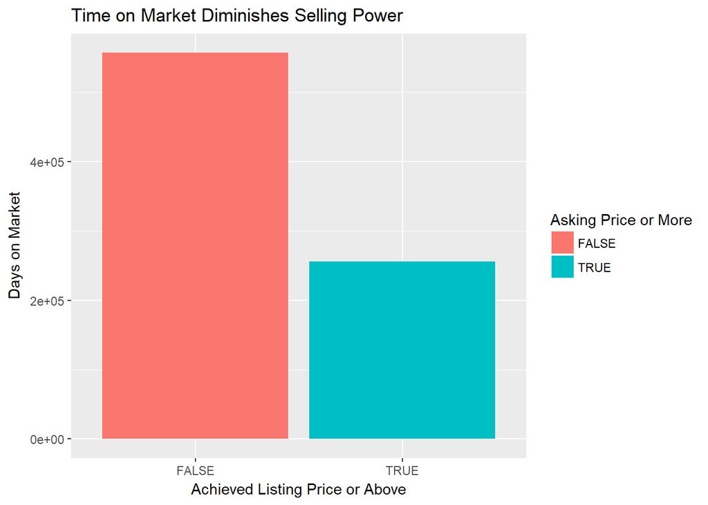

```r
#cbPalette <- c("#999999", "#E69F00", "#56B4E9", "#009E73", "#F0E442", "#0072B2", "#D55E00", "#CC79A7")
#ggplot <- function(...) ggplot2::ggplot(...) + #scale_color_brewer(palette="Spectral")
ggplot(dat, aes(x=as.factor(BooleanRatio), y=DOM, fill = as.factor(BooleanRatio))) + geom_bar(stat="identity")+
labs(title = "Time on Market Diminishes Selling Power") +
ylab("Days on Market") +
xlab("Achieved Listing Price or Above")+
guides(fill=guide_legend(title="Asking Price or More"))
```

I take a look at what the standard deviation is in regard to DOM as even with clipping in Azure ML of the outliers, all of the plots were I examine the variables along Days on Market (DOM) the outliers are still quite evident.

```r
sd(dat$DOM)
```

```
## [1] 53.49645
```

```r
SDom <- scale(dat$DOM, center = TRUE, scale = TRUE)
```

It makes sense to look at another numeric variable with the standard deviation taken into account.

```r
sd(dat$PricePerSQFT)
```

```
## [1] 47.42085
```

```r
sdSQFT <- sd(dat$PricePerSQFT)
```

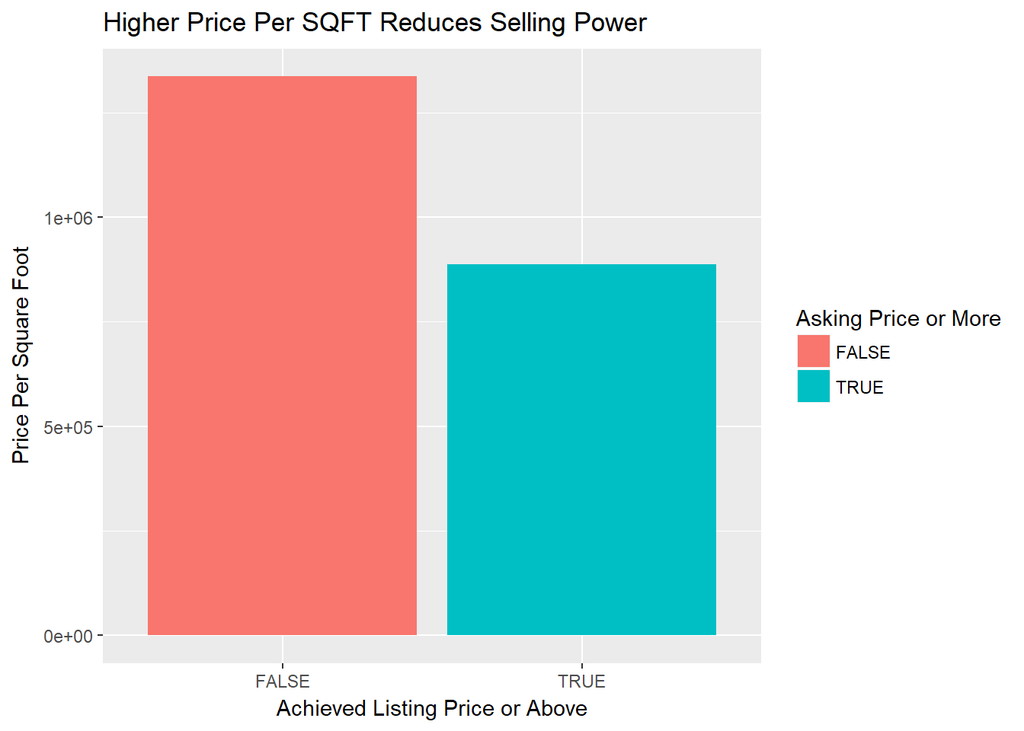

```r
ggplot(dat, aes(x=as.factor(BooleanRatio), y=PricePerSQFT, fill = as.factor(BooleanRatio))) + geom_bar(stat="identity")+
labs(title = "Higher Price Per SQFT Reduces Selling Power") +
ylab("Price Per Square Foot") +
xlab("Achieved Listing Price or Above")+
guides(fill=guide_legend(title="Asking Price or More"))
```

```r
Lmonth<- factor(dat$ListMonth, levels = c("1", "2", "3", "4", "5", "6", "7", "8", "9", "10", "11", "12"))
Pmonth<-factor(dat$OffMarketMonth, levels = c("1", "2", "3", "4", "5", "6", "7", "8", "9", "10", "11", "12"))
Cmonth<-factor(dat$ClosedMonth, levels = c("1", "2", "3", "4", "5", "6", "7", "8", "9", "10", "11", "12"))
SellAgRank<- factor(dat$SellAgentRanked, levels = c("Low", "Medium", "High"))
ListAgRank<- factor(dat$ListAgentRank, levels = c("Low", "Medium", "High"))
Weekday <- factor(dat$DayOfWeekListed, levels = c("Sunday", "Monday", "Tuesday", "Wednesday", "Thursday", "Friday", "Saturday"))
#Lmonths<- factor(dat$ListMonth, levels = c("January", "February", "March", "April", "May", "June", "July", "August", "September", "October", "November", "December"))
```

A rule that most real estate professionals stand by is that if one lists their property in the colder months, they will ultimately capture more revenue on their home sale. This is because of a basic supply and demand premise. The general idea that home sellers stand by is to list in the spring, when the grass is green the property looks its best. However, with a flood of inventory on the market, buyers have more options and generally should be able to negociate more off the listing price. Thusly, more supply, less demand. I did an exploration of the data to confirm or deny this premise, by looking at the listing months, pending months, and closed months. I did a side by side comparison of frequency count and proportionally in regard to our standard of measurement boolean - (did this sell for list price or higher?) The results were interesting, and seeminly contrary, at least for the past few years in this section of RI, to common thought in regard to listing real estate.

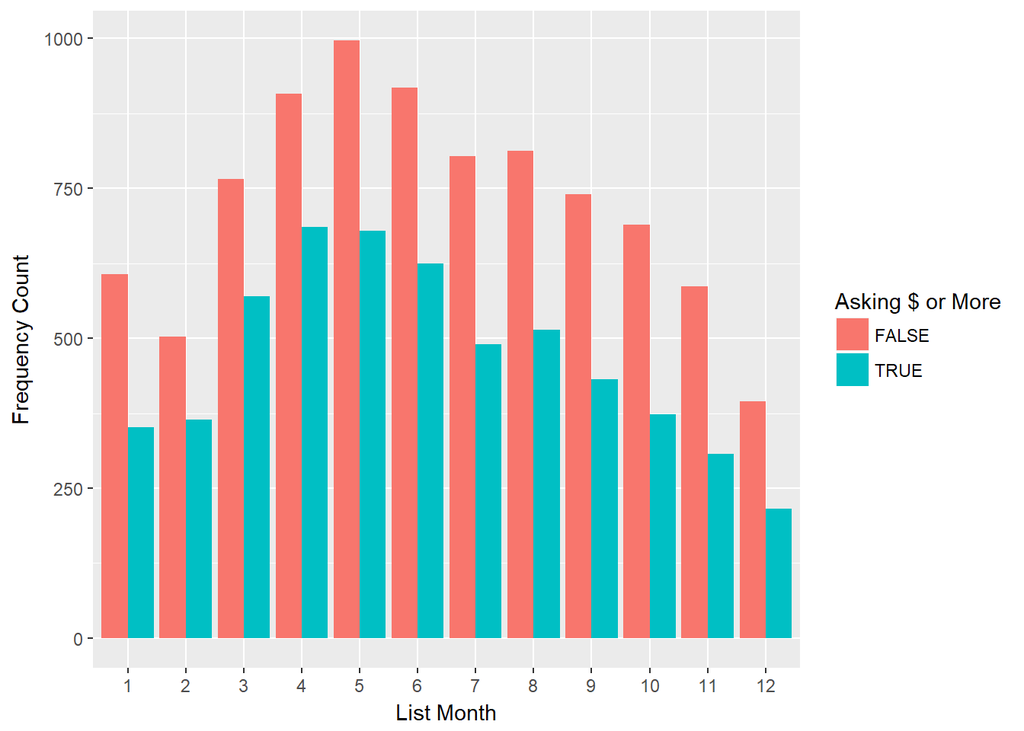

```r
p2<- ggplot(dat, aes(x=Lmonth, fill = as.factor(BooleanRatio))) + geom_bar(position="dodge")+
xlab("List Month") +
ylab("Frequency Count")+
guides(fill=guide_legend(title="Asking $ or More"))
p2
```

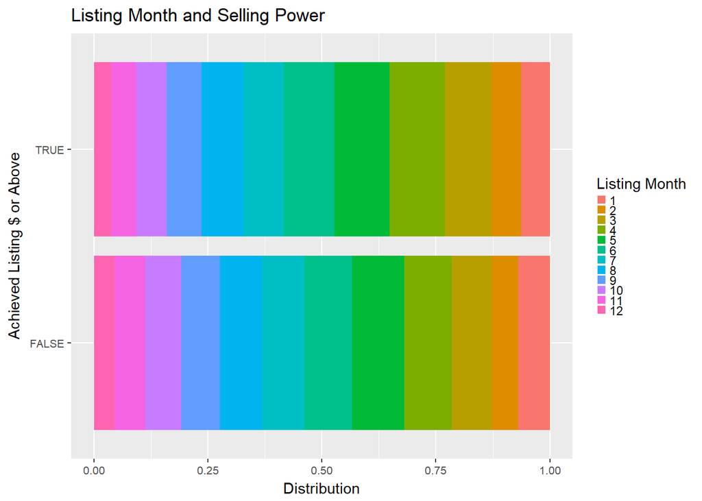

```r
p1 <- ggplot(dat, aes(x=as.factor(BooleanRatio), fill = Lmonth))+
geom_bar(position ="fill")+
labs(title = "Listing Month and Selling Power") +
ylab("Distribution") +
xlab("Achieved Listing $ or Above")+
guides(fill=guide_legend(title="Listing Month"))+
theme(legend.key.size =  unit(0.1, "in"))+
theme(axis.text = element_text(size = 8))+
coord_flip()
p1
```

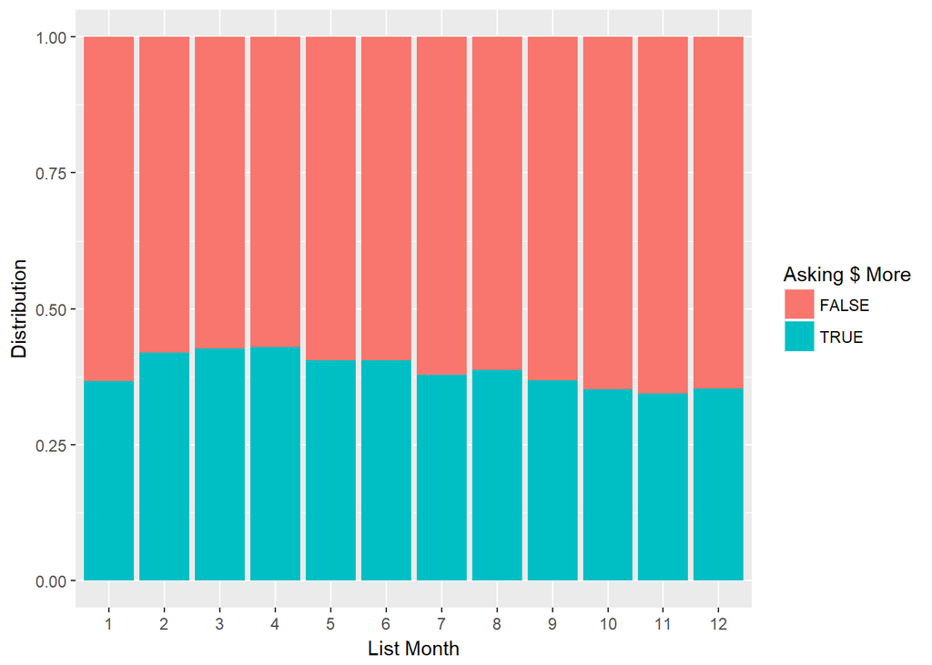

```r
p20<- ggplot(dat, aes(x=Lmonth, fill = as.factor(BooleanRatio))) + geom_bar(position="fill")+
xlab("List Month") +
ylab("Distribution")+
guides(fill=guide_legend(title="Asking $ More"))
p20
```

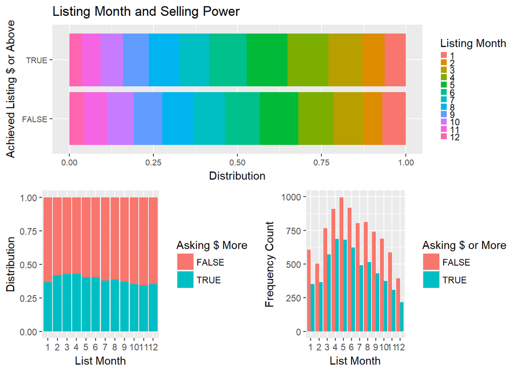

```r
require(gridExtra)
grid.arrange(p1, arrangeGrob(p20,p2, ncol=2), ncol=1)
```

```r
p3<- ggplot(dat, aes(x=Pmonth, fill = as.factor(BooleanRatio))) + geom_bar(position="dodge")+
xlab("Pending Month") +
ylab("Frequency Count")+
guides(fill=guide_legend(title="Asking $ or More"))
```

```r
p4 <- ggplot(dat, aes(x=as.factor(BooleanRatio), fill = Pmonth)) +
geom_bar(position = "fill")+
labs(title = "Pending Month and Selling Power") +
ylab("Distribution") +
xlab("Achieved Listing $ or Above")+
guides(fill=guide_legend(title="Pending Month"))+
theme(legend.key.size =  unit(0.1, "in"))+
theme(axis.text = element_text(size = 8))+
coord_flip()
```

```r
p21<- ggplot(dat, aes(x=Pmonth, fill = as.factor(BooleanRatio))) + geom_bar(position="fill")+
xlab("Pending Month") +
ylab("Distribution")+
guides(fill=guide_legend(title="Asking $ More"))
```

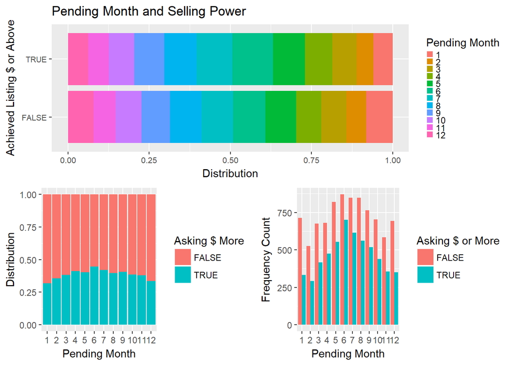

```r
require(gridExtra)
grid.arrange(p4, arrangeGrob(p21,p3, ncol=2), ncol=1)
```

```r
p5<- ggplot(dat, aes(x=Cmonth, fill = as.factor(BooleanRatio))) + geom_bar(position="dodge")+
xlab("Closed Month") +
ylab("Frequency Count")+
guides(fill=guide_legend(title="Asking $ or More"))
```

```r
p6 <- ggplot(dat, aes(x=as.factor(BooleanRatio), fill = Cmonth)) +
geom_bar(position = "fill")+
labs(title = "Closed Month and Selling Power") +
ylab("Distribution") +
xlab("Achieved Listing $ or Above")+
guides(fill=guide_legend(title="Closed Month"))+
theme(legend.key.size =  unit(0.1, "in"))+
theme(axis.text = element_text(size = 8))+
coord_flip()
```

```r
p22<- ggplot(dat, aes(x=Cmonth, fill = as.factor(BooleanRatio))) + geom_bar(position="fill")+
xlab("Closed Month") +
ylab("Distribution")+
guides(fill=guide_legend(title="Asking $ More"))
```

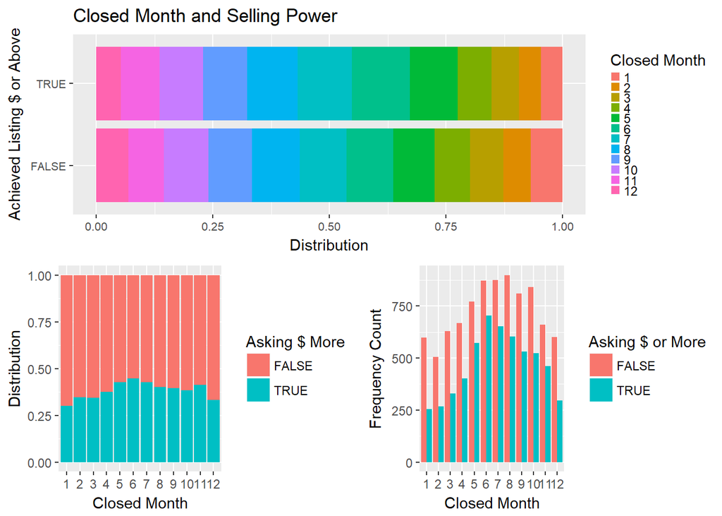

```r
require(gridExtra)
grid.arrange(p6, arrangeGrob(p22,p5, ncol=2), ncol=1)
```

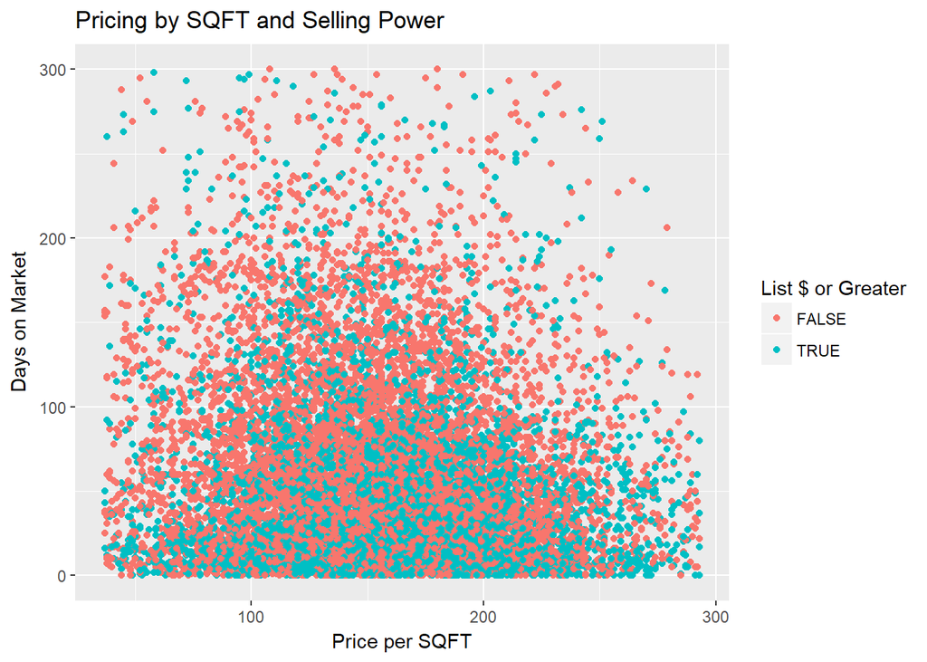

```r
p7<- ggplot(dat, aes(x=PricePerSQFT, y= DOM, colour = as.factor(BooleanRatio))) + geom_point()+
labs(title = "Pricing by SQFT and Selling Power") +
ylab("Days on Market") +
xlab("Price per SQFT")+
guides(colour=guide_legend(title="List $ or Greater"))
p7
```

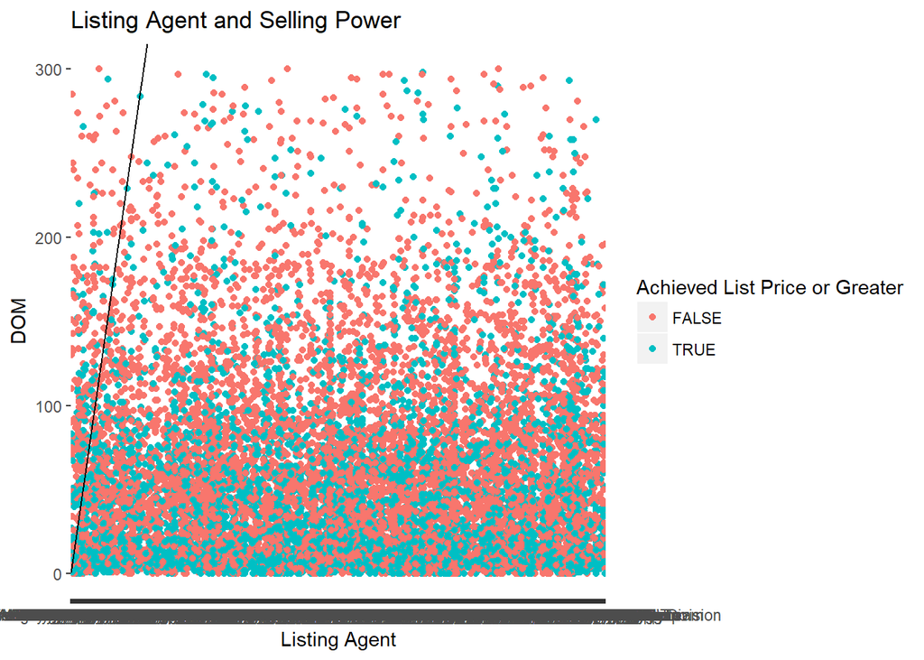

```r
p8<- ggplot(dat, aes(x= ListAgent, y = DOM, colour = as.factor(BooleanRatio))) + geom_point()+
labs(title = "Listing Agent and Selling Power") +
xlab("Listing Agent") +
ylab("DOM")+
geom_abline()+
guides(colour=guide_legend(title="Achieved List Price or Greater"))
#theme(axis.text.x = element_text(angle = 90, hjust = 1))
p8
```

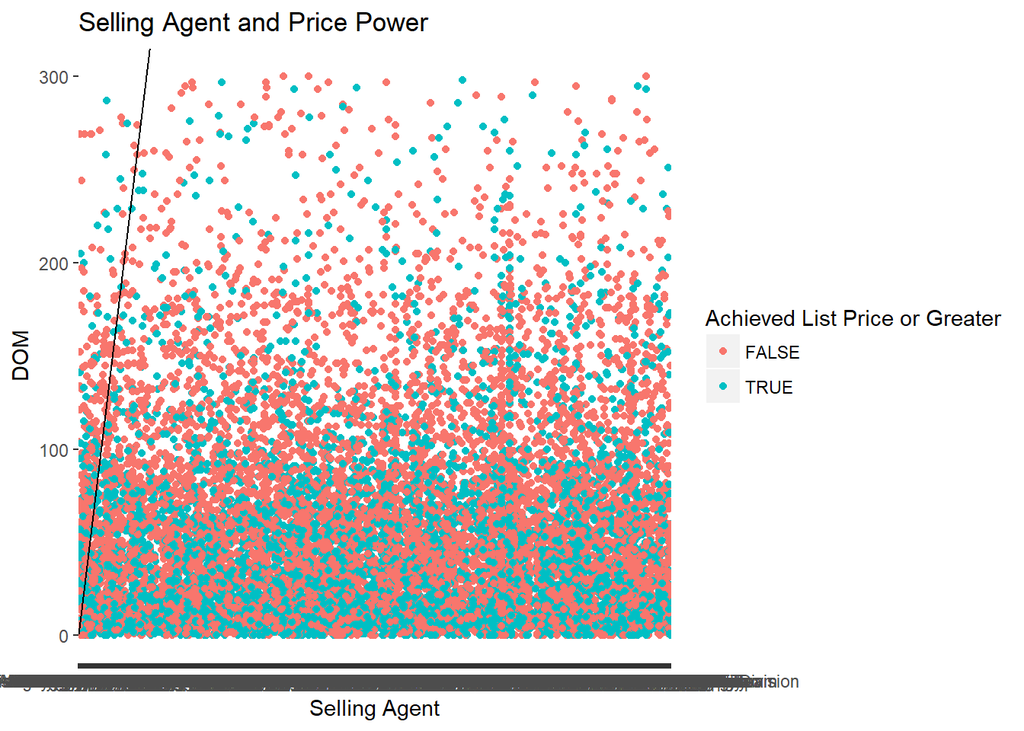

```r
p9<- ggplot(dat, aes(x= SellAgent, y = DOM, colour = as.factor(BooleanRatio))) + geom_point()+
labs(title = "Selling Agent and Price Power") +
xlab("Selling Agent") +
ylab("DOM")+
geom_abline()+
guides(colour=guide_legend(title="Achieved List Price or Greater"))
#theme(axis.text.x = element_text(angle = 90, hjust = 1))
p9
```

We clearly have an issue with the amount of variables in regard to listing agent and selling agent. Furthermore, on examination, we see that over the course of over almost 3 years, several agents had hardly ever sold a home at all. These are paths in our desicion trees that we may not need to follow. Therefore, we are going to attempt to put these agents in different buckets, visualized by histograms, on how many homes they actually sold. This begged for further investigation, and potential segmentation of the variable.

```r
nrow(dat)
```

```
## [1] 14331
```

```r
ListAgentSynched <- table(dat$ListAgent)
ListAgentSynched <- as.data.frame(table(dat$ListAgent))
nrow(ListAgentSynched)
```

```
## [1] 2203
```

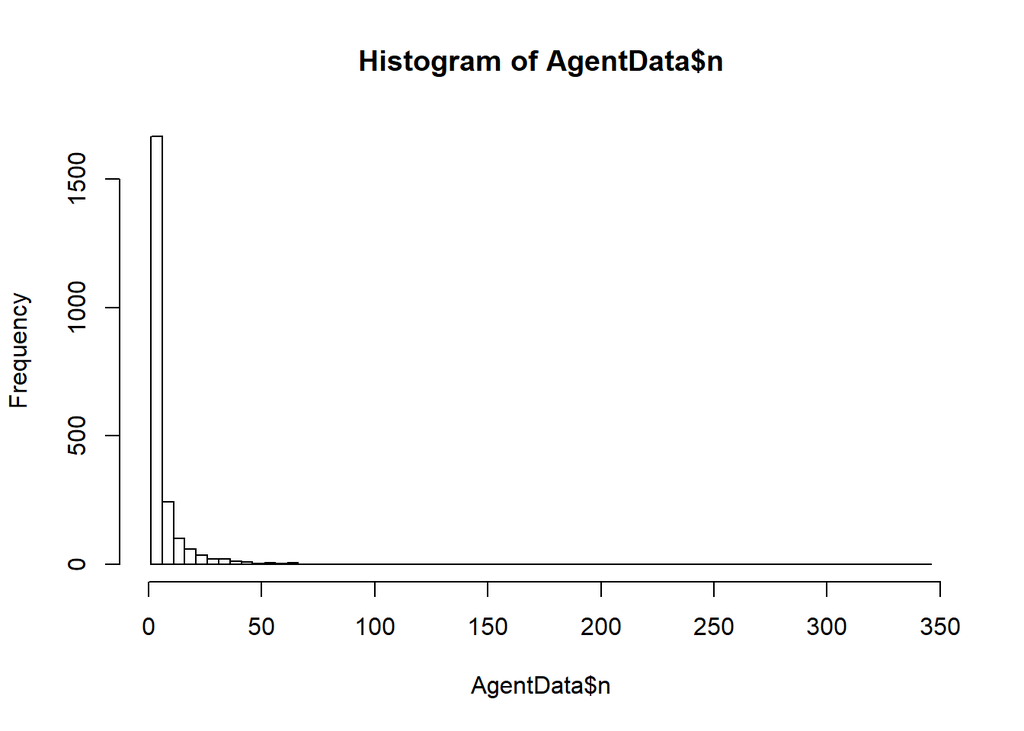

```r
AgentData <- dat %>%
  count(ListAgent)
hist(AgentData$n, breaks = seq(1, 350, by = 5))
```

```r
nrow(dat)
```

```
## [1] 14331
```

```r
SellAgentSynched <- table(dat$SellAgent)
SellAgentSynched <- as.data.frame(table(dat$SellAgent))
nrow(SellAgentSynched)
```

```
## [1] 2614
```

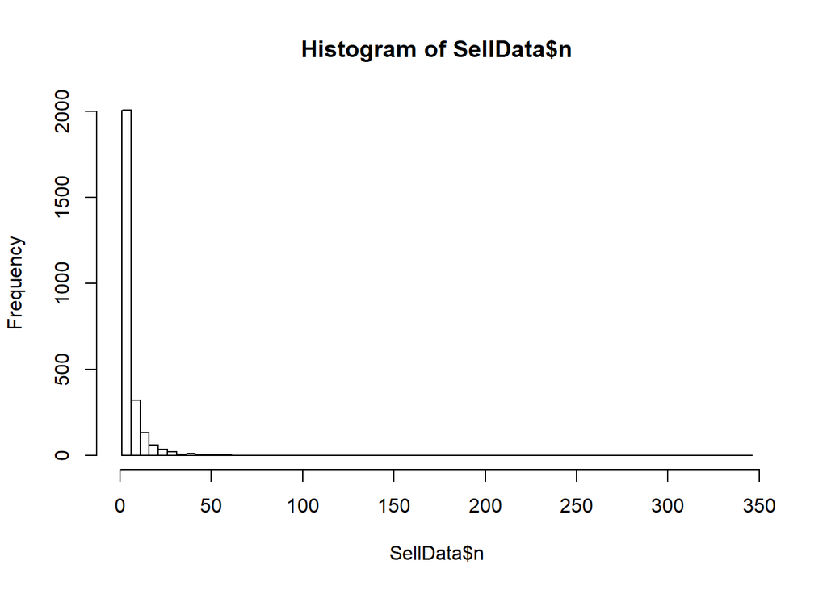

```r
SellData <- dat %>%
  count(SellAgent)
hist(SellData$n, breaks = seq(1, 350, by = 5))
```

There is a huge disperity between those who are selling more than a handful of homes a year, and those who are not. I create different buckets, segmenting these agents into “low”, “medium”, and “high” producers.

```r
# High > 20, Medium > 12, Low
AgentData <- AgentData %>% mutate(AgentVolume = ifelse(n < 12, "Low", ifelse(n < 20, "Medium", "High")))
AgVol <- factor(AgentData$AgentVolume, levels = c("Low", "Medium", "High"))
p10 <- ggplot(AgentData, aes(x=AgVol, fill = AgentVolume)) + geom_bar()+
xlab("Listing Agent Production Level") +
ylab("Sales Frequency Count")+
guides(fill=guide_legend(title="Agent Volume"))
```

```r
# High > 20, Medium > 12, Low
SellData <- SellData %>% mutate(AgentVolume = ifelse(n < 12, "Low", ifelse(n < 20, "Medium", "High")))
SAgVol <- factor(SellData$AgentVolume, levels = c("Low", "Medium", "High"))
p11 <- ggplot(SellData, aes(x=SAgVol, fill = AgentVolume)) + geom_bar()+
xlab("Selling Agent Production Level") +
ylab("Sales Frequency Count")+
guides(fill=guide_legend(title="Agent Volume"))
```

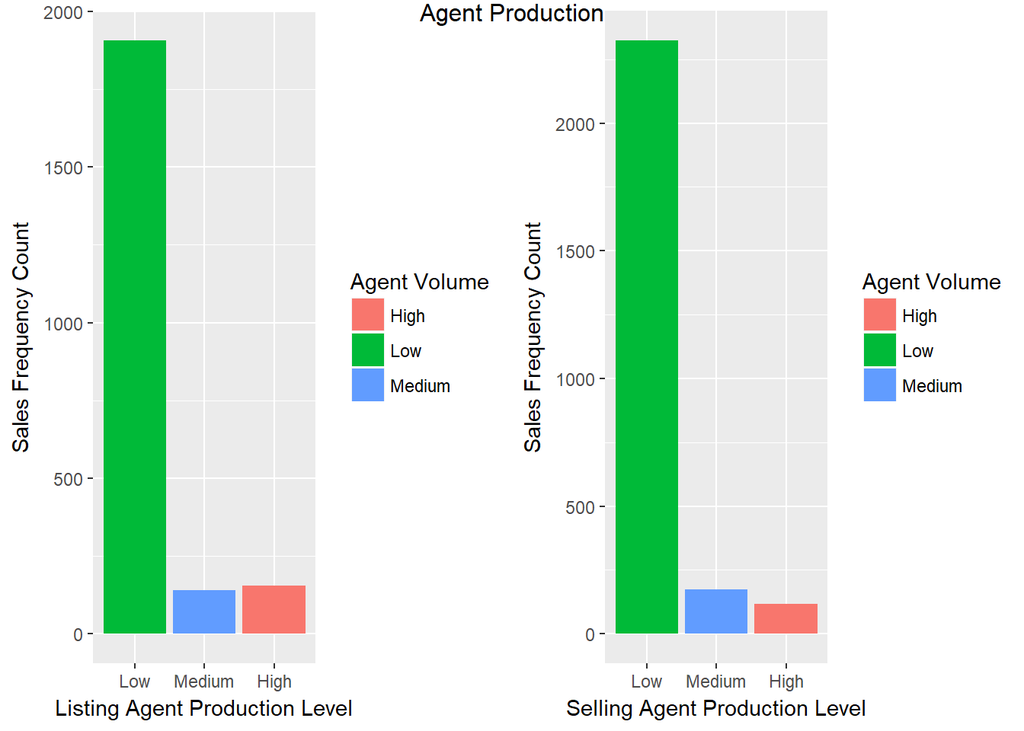

```r
require(gridExtra)
grid.arrange(p10, p11, ncol=2)
pushViewport(viewport(layout = grid.layout(4, 2, heights = unit(c(2, 28, 28), "null"))))
grid.text("Agent Production", vp = viewport(layout.pos.row = 1, layout.pos.col = 1:2))
```

```r
#p13<- ggplot(dat, aes(x=ListAgRank, fill =as.factor(BooleanRatio)))+
#geom_bar(position = "dodge")+
#labs(title = "Listing Agent Volume and Performance",
#     subtitle = "High = >20 Sales, Medium = 12-20 Sales, Low = <12 Sales") +
#ylab("Frequency Count") +
#xlab("Listing Agent Ranking")+
#guides(fill=guide_legend(title="List $ or Greater"))+
#coord_flip()
#p13
```

```r
#p14<- ggplot(dat, aes(x=ListAgRank, fill #=as.factor(BooleanRatio)))+
#geom_bar(position = "fill")+
#labs(title = "Listing Agent Volume and Performance",
#     subtitle = "High = >20 Sales, Medium = 12-20 #Sales, Low = <12 Sales") +
#ylab("Distribution") +
#xlab("Listing Agent Ranking")+
#guides(fill=guide_legend(title="List $ or Greater"))+
#coord_flip()
#p14
```

```r
#require(gridExtra)
#grid.arrange(p13, p14, ncol=2)
```

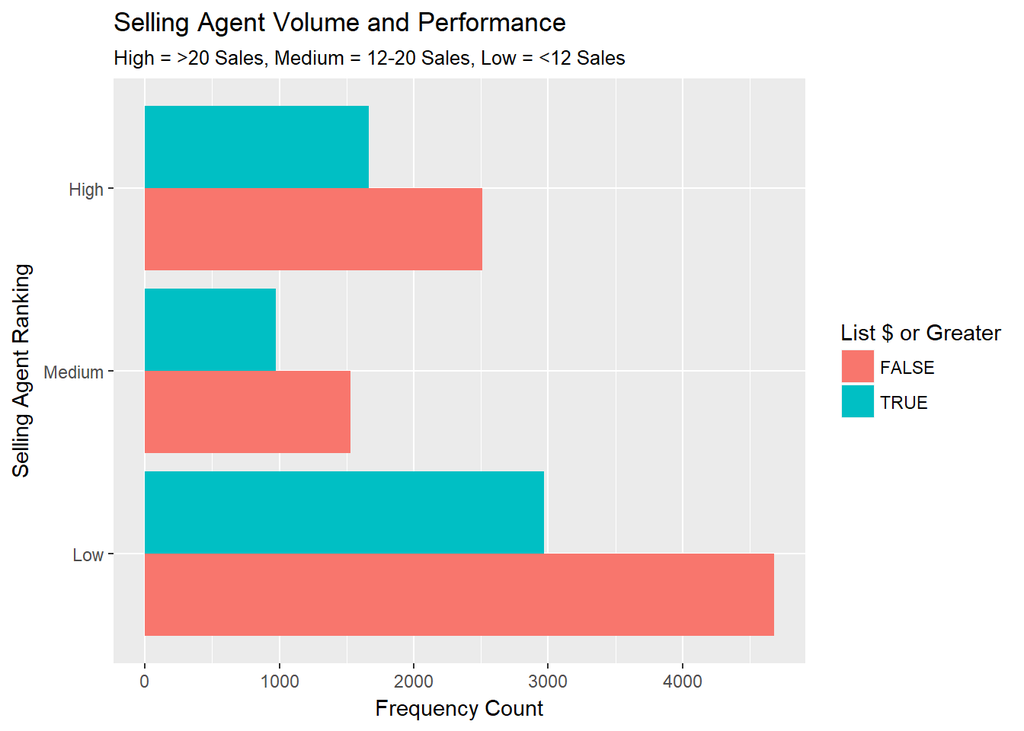

```r
p15<- ggplot(dat, aes(x=SellAgRank, fill =as.factor(BooleanRatio)))+
geom_bar(position = "dodge")+
labs(title = "Selling Agent Volume and Performance",
     subtitle = "High = >20 Sales, Medium = 12-20 Sales, Low = <12 Sales") +
ylab("Frequency Count") +
xlab("Selling Agent Ranking")+
guides(fill=guide_legend(title="List $ or Greater"))+
coord_flip()
p15
```

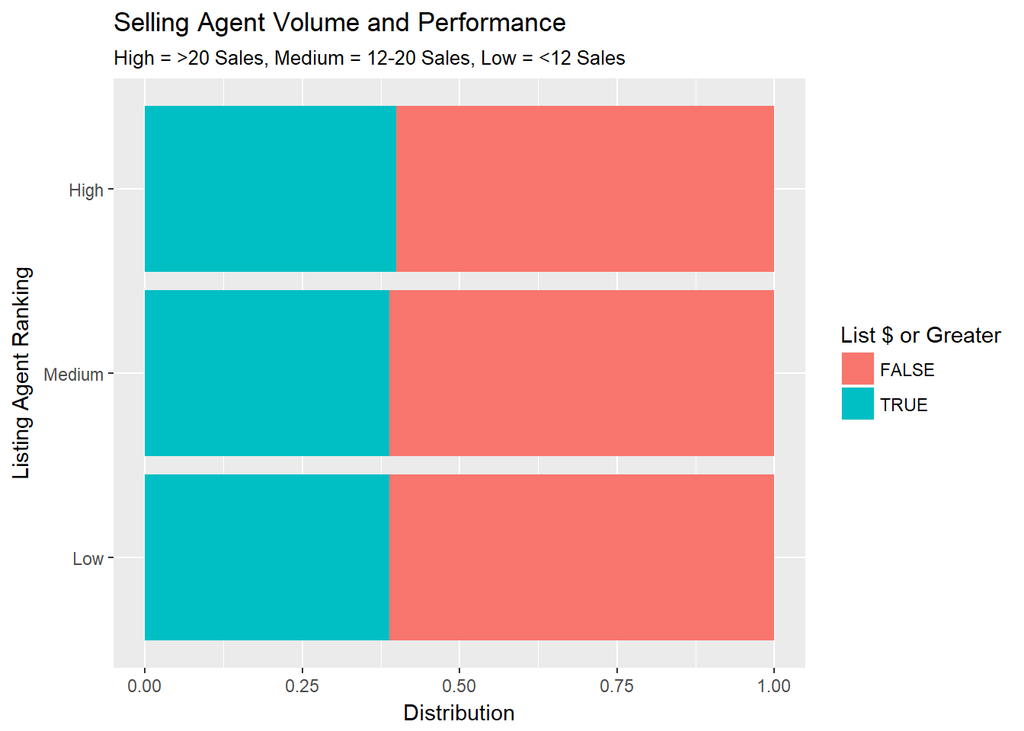

```r
p16<- ggplot(dat, aes(x=SellAgRank, fill =as.factor(BooleanRatio)))+
geom_bar(position = "fill")+
labs(title = "Selling Agent Volume and Performance",
     subtitle = "High = >20 Sales, Medium = 12-20 Sales, Low = <12 Sales") +
ylab("Distribution") +
xlab("Listing Agent Ranking")+
guides(fill=guide_legend(title="List $ or Greater"))+
coord_flip()
p16
```

```r
#require(gridExtra)
#grid.arrange(p15, p16, ncol=2)
```

Now let’s take a look at the incredible number of different observations within the Listing and Selling Agency variables.

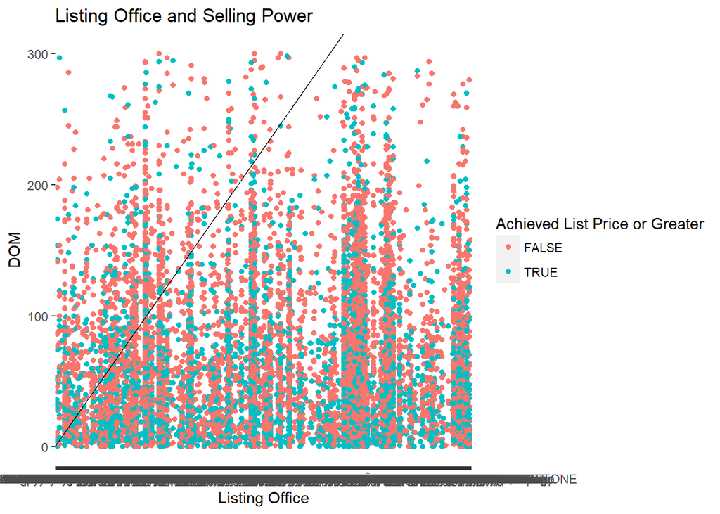

```r
p30<- ggplot(dat, aes(x=ListOffice, y = DOM, colour = as.factor(BooleanRatio))) + geom_point()+
labs(title = "Listing Office and Selling Power") +
xlab("Listing Office") +
ylab("DOM")+
geom_abline()+
guides(colour=guide_legend(title="Achieved List Price or Greater"))
#theme(axis.text.x = element_text(angle = 90, hjust = 1))
p30
```

Now we will apply the same method to the selling offices.

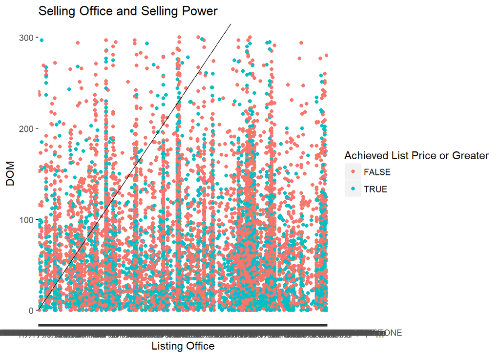

```r
p31<- ggplot(dat, aes(x=SellOffice, y = DOM, colour = as.factor(BooleanRatio))) + geom_point()+
labs(title = "Selling Office and Selling Power") +
xlab("Listing Office") +
ylab("DOM")+
geom_abline()+
guides(colour=guide_legend(title="Achieved List Price or Greater"))
#theme(axis.text.x = element_text(angle = 90, hjust = 1))
p31
```

Again we see that there is something interesting going on with the plot - but there is too much information to be clear. Therefore, we’ll try some binning.

```r
nrow(dat)
```

```
## [1] 14331
```

```r
ListOfficeSynched <- table(dat$ListOffice)
ListOfficeSynched <- as.data.frame(table(dat$ListOffice))
nrow(ListOfficeSynched)
```

```
## [1] 455
```

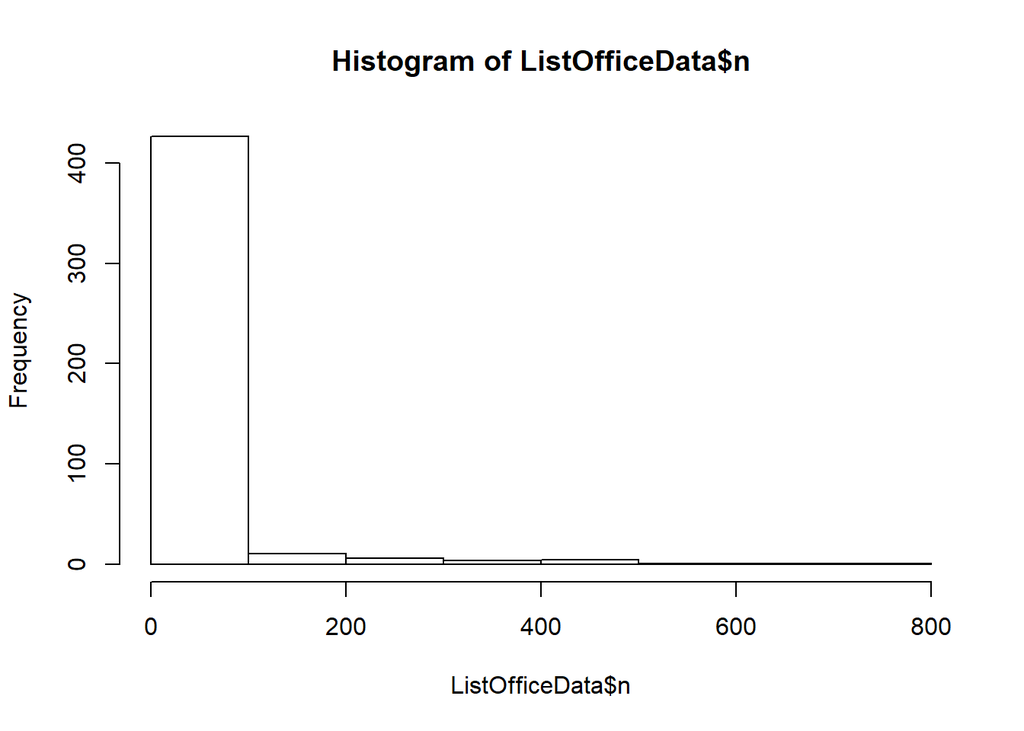

```r
ListOfficeData <- dat %>%
  count(ListOffice)
hist(ListOfficeData$n, breaks = 10)
```

```r
nrow(dat)
```

```
## [1] 14331
```

```r
SellOfficeSynched <- table(dat$SellOffice)
SellOfficeSynched <- as.data.frame(table(dat$SellOffice))
nrow(SellOfficeSynched)
```

```
## [1] 473
```

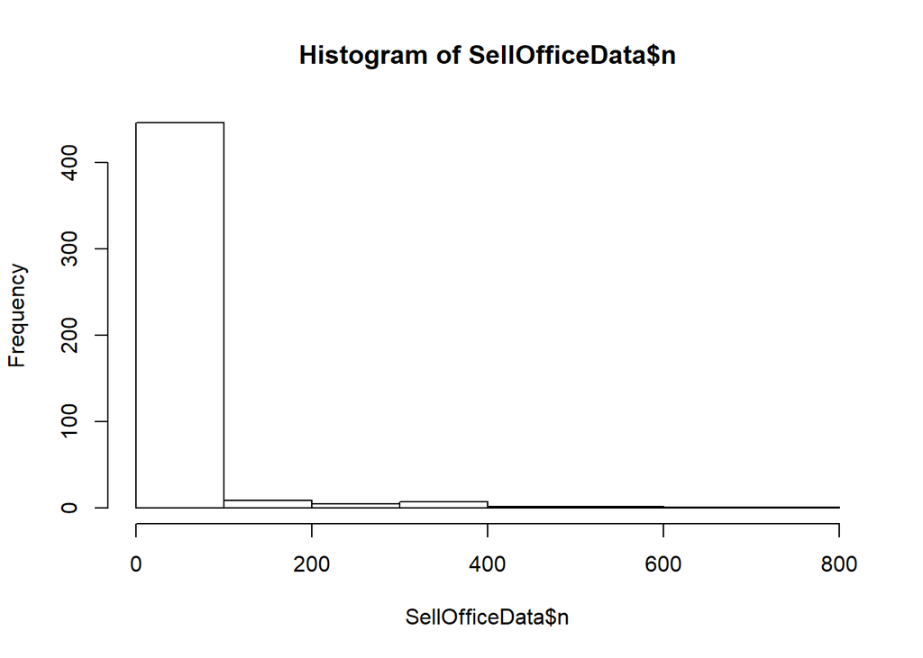

```r
SellOfficeData <- dat %>%
  count(SellOffice)
hist(SellOfficeData$n, breaks = 10)
```

```r
# High > 20, Medium > 12, Low
ListOfficeData <- ListOfficeData %>% mutate(ListOfficeVolume = ifelse(n < 12, "Low", ifelse(n < 20, "Medium", "High")))
LOfficeVol <- factor(ListOfficeData$ListOfficeVolume, levels = c("Low", "Medium", "High"))
```

```r
# High > 20, Medium > 12, Low
SellOfficeData <- SellOfficeData %>% mutate(SellOfficeVolume = ifelse(n < 12, "Low", ifelse(n < 20, "Medium", "High")))
SOfficeVol <- factor(ListOfficeData$ListOfficeVolume, levels = c("Low", "Medium", "High"))
```

```r
# High > 20, Medium > 12, Low
AgentData <- AgentData %>% mutate(AgentVolume = ifelse(n < 12, "Low", ifelse(n < 20, "Medium", "High")))
AgVol <- factor(AgentData$AgentVolume, levels = c("Low", "Medium", "High"))
p10 <- ggplot(AgentData, aes(x=AgVol, fill = AgentVolume)) + geom_bar()+
xlab("Listing Agent Production Level") +
ylab("Sales Frequency Count")+
guides(fill=guide_legend(title="Agent Volume"))
```

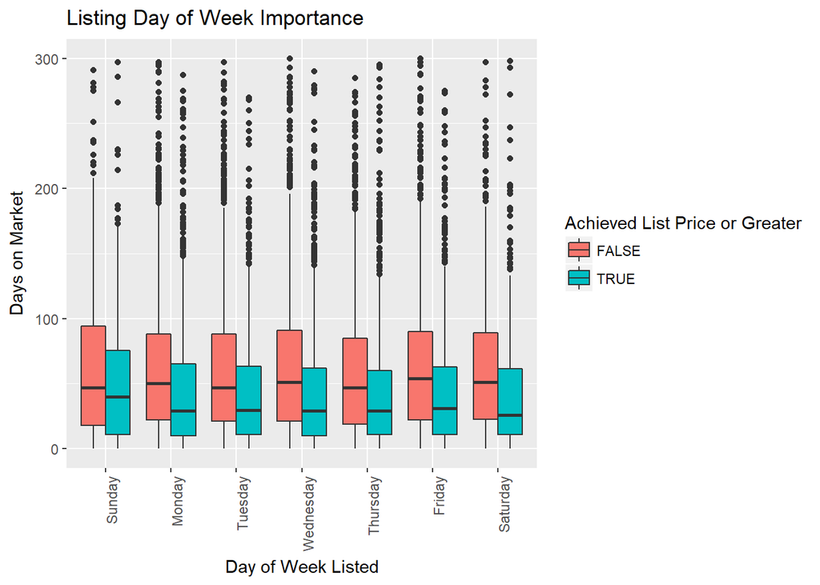

```r
p18<- ggplot(dat, aes(x=Weekday, y = DOM, fill = as.factor(BooleanRatio))) + geom_boxplot()+
labs(title = "Listing Day of Week Importance") +
xlab("Day of Week Listed") +
ylab("Days on Market")+
guides(fill=guide_legend(title="List $ or Greater"))+
theme(axis.text.x = element_text(angle = 90, hjust = 1))+
guides(fill=guide_legend(title="Achieved List Price or Greater"))
p18
```

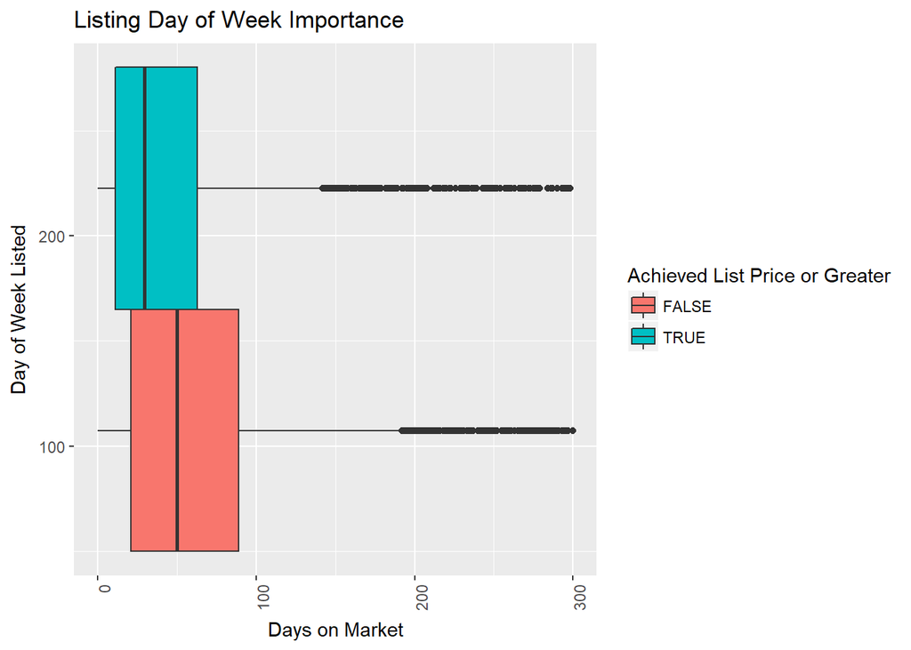

```r
p25<- ggplot(dat, aes(x=PricePerSQFT, y = DOM, fill = as.factor(BooleanRatio))) + geom_boxplot()+
labs(title = "Listing Day of Week Importance") +
xlab("Day of Week Listed") +
ylab("Days on Market")+
guides(fill=guide_legend(title="List $ or Greater"))+
theme(axis.text.x = element_text(angle = 90, hjust = 1))+
guides(fill=guide_legend(title="Achieved List Price or Greater"))+
coord_flip()
p25
```

```r
#   ![Caption for the picture.](/path/to/image.png)
```

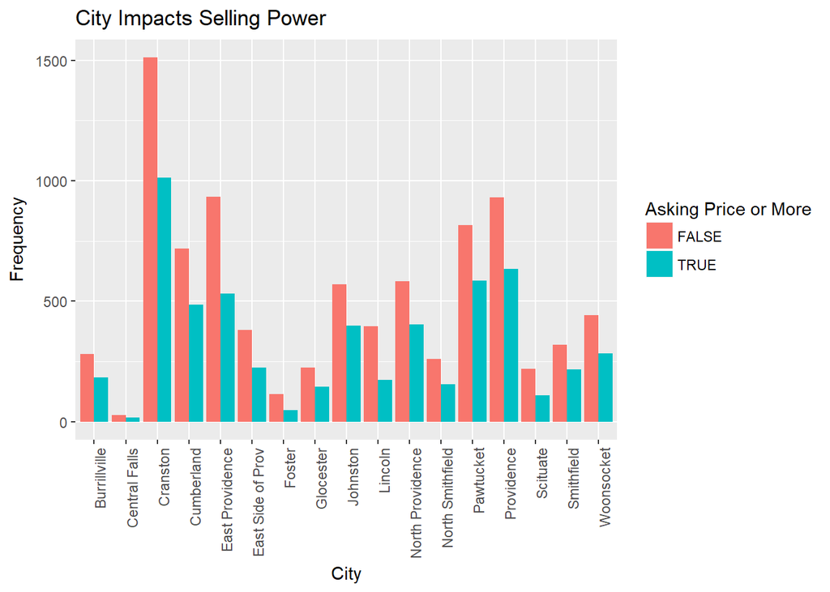

```r
ggplot(dat, aes(x=City, fill = as.factor(BooleanRatio))) + geom_bar(position = "dodge")+
labs(title = "City Impacts Selling Power") +
ylab("Frequency") +
xlab("City")+
guides(fill=guide_legend(title="Asking Price or More"))+
theme(axis.text.x = element_text(angle = 90, hjust = 1))
```

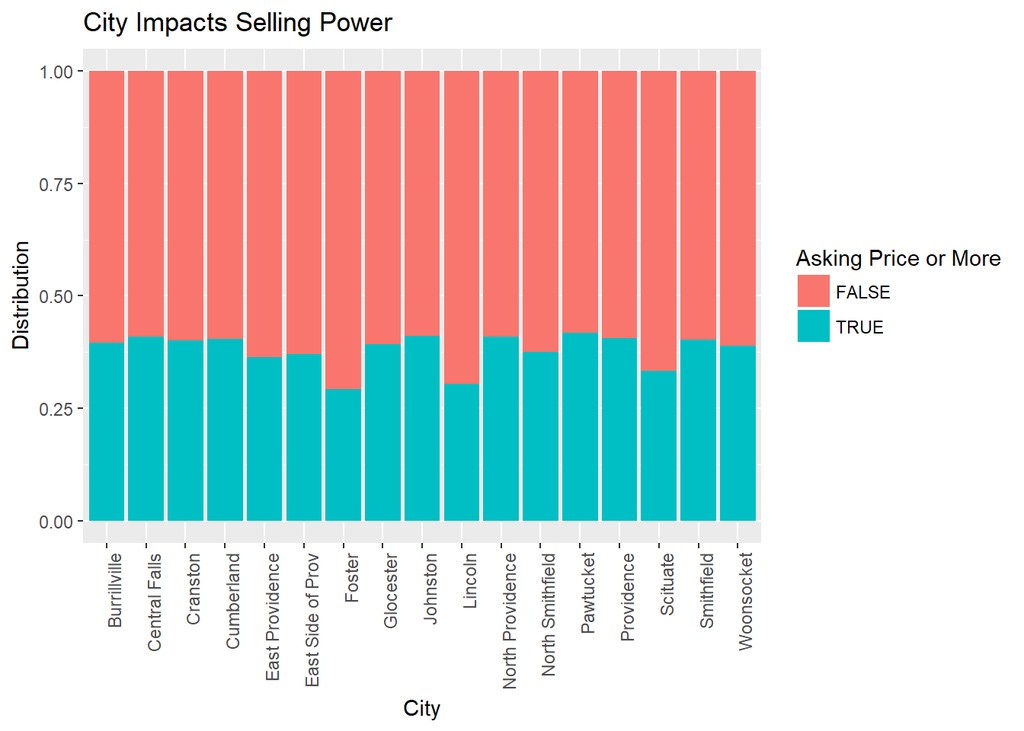

```r
ggplot(dat, aes(x=City, fill = as.factor(BooleanRatio))) + geom_bar(position = "fill")+
labs(title = "City Impacts Selling Power") +
ylab("Distribution") +
xlab("City")+
guides(fill=guide_legend(title="Asking Price or More"))+
theme(axis.text.x = element_text(angle = 90, hjust = 1))
```

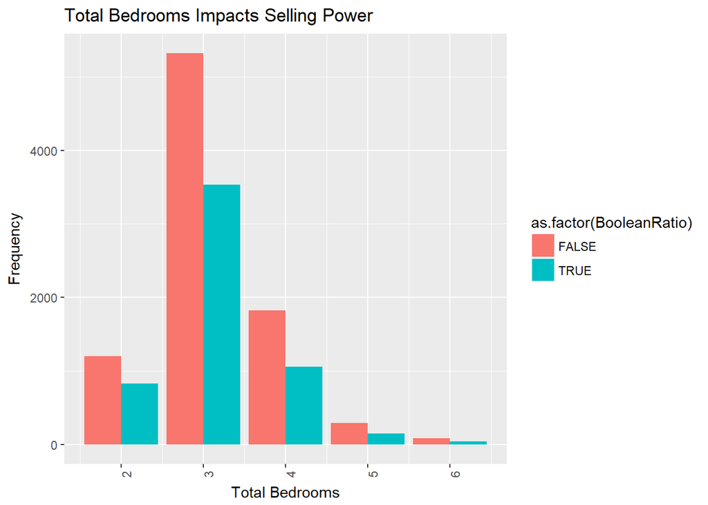

```r
ggplot(dat, aes(x=TotalBedrooms, fill = as.factor(BooleanRatio))) + geom_bar(position = "dodge")+
labs(title = "Total Bedrooms Impacts Selling Power") +
ylab("Frequency") +
xlab("Total Bedrooms")+
guides(colour=guide_legend(title="Asking Price or More"))+
theme(axis.text.x = element_text(angle = 90, hjust = 1))
```

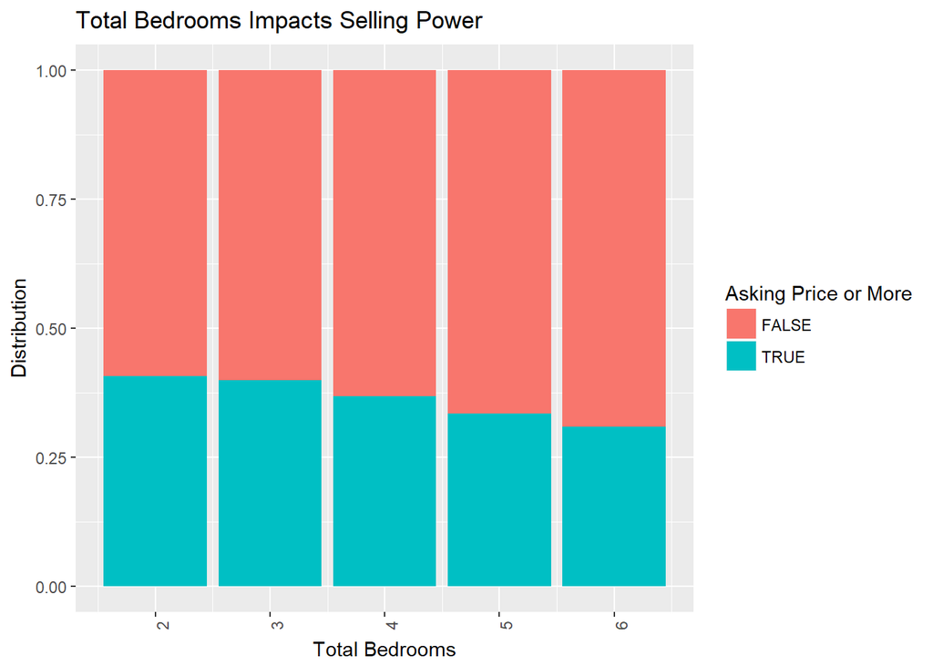

```r
ggplot(dat, aes(x=TotalBedrooms, fill = as.factor(BooleanRatio))) + geom_bar(position = "fill")+
labs(title = "Total Bedrooms Impacts Selling Power") +
ylab("Distribution") +
xlab("Total Bedrooms")+
guides(fill=guide_legend(title="Asking Price or More"))+
theme(axis.text.x = element_text(angle = 90, hjust = 1))
```